# R Notebook

Eric Schneider

## Set up rmd and import needed package libraries for analysis

```r
# clean up workspace environment
rm(list = ls())

# all packages used for the assignment
library(dplyr)
library(DataComputing)
library(rvest)
library(tidyr)
library(ggplot2)
library(mosaic)
library(cowplot)
```

## Load in Data from websites to make data tables for research

```r
page <- "https://www.basketball-reference.com/leaders/pts_per_g_career.html"
tableList <- page %>%
  read_html() %>%
  html_nodes(css = "table") %>%
  html_table(fill = TRUE)
allTime <- (tableList[[3]])
```

```r
page1 <- "https://www.basketball-reference.com/leagues/NBA_2019_per_game.html"
tableList1 <- page1 %>%
  read_html() %>%
  html_nodes(css = "table") %>%
  html_table(fill = TRUE)
g20189 <- (tableList1[[1]])
```

```r
page2 <- "https://www.basketball-reference.com/leagues/NBA_2018_per_game.html"
tableList2 <- page2 %>%
  read_html() %>%
  html_nodes(css = "table") %>%
  html_table(fill = TRUE)
g20178 <- (tableList2[[1]])
```

```r
page3 <- "https://www.basketball-reference.com/leagues/NBA_2017_per_game.html"
tableList3 <- page3 %>%
  read_html() %>%
  html_nodes(css = "table") %>%
  html_table(fill = TRUE)
g20167 <- (tableList3[[1]])
```

# Inspect new imported data tables to see format and variable names

```r
head(g20167)
```

|  | Rk | Player | Pos | Age | Tm | G | GS | MP | FG | FGA | FG% | 3P | 3PA | 3P% | 2P | 2PA | 2P% | eFG% | FT | FTA | FT% | ORB | DRB | TRB | AST | STL | BLK | TOV | PF | … |
| --- | --- | --- | --- | --- | --- | --- | --- | --- | --- | --- | --- | --- | --- | --- | --- | --- | --- | --- | --- | --- | --- | --- | --- | --- | --- | --- | --- | --- | --- | --- |
| 1 | 1 | Álex Abrines | SG | 23 | OKC | 68 | 6 | 15.5 | 2.0 | 5.0 | .393 | 1.4 | 3.6 | .381 | 0.6 | 1.4 | .426 | .531 | 0.6 | 0.7 | .898 | 0.3 | 1.0 | 1.3 | 0.6 | 0.5 | 0.1 | 0.5 | 1.7 | … |
| 2 | 2 | Quincy Acy | PF | 26 | TOT | 38 | 1 | 14.7 | 1.8 | 4.5 | .412 | 1.0 | 2.4 | .411 | 0.9 | 2.1 | .413 | .521 | 1.2 | 1.6 | .750 | 0.5 | 2.5 | 3.0 | 0.5 | 0.4 | 0.4 | 0.6 | 1.8 | … |
| 3 | 2 | Quincy Acy | PF | 26 | DAL | 6 | 0 | 8.0 | 0.8 | 2.8 | .294 | 0.2 | 1.2 | .143 | 0.7 | 1.7 | .400 | .324 | 0.3 | 0.5 | .667 | 0.3 | 1.0 | 1.3 | 0.0 | 0.0 | 0.0 | 0.3 | 1.5 | … |
| 4 | 2 | Quincy Acy | PF | 26 | BRK | 32 | 1 | 15.9 | 2.0 | 4.8 | .425 | 1.1 | 2.6 | .434 | 0.9 | 2.2 | .414 | .542 | 1.3 | 1.8 | .754 | 0.6 | 2.8 | 3.3 | 0.6 | 0.4 | 0.5 | 0.6 | 1.8 | … |
| 5 | 3 | Steven Adams | C | 23 | OKC | 80 | 80 | 29.9 | 4.7 | 8.2 | .571 | 0.0 | 0.0 | .000 | 4.7 | 8.2 | .572 | .571 | 2.0 | 3.2 | .611 | 3.5 | 4.2 | 7.7 | 1.1 | 1.1 | 1.0 | 1.8 | 2.4 | … |
| 6 | 4 | Arron Afflalo | SG | 31 | SAC | 61 | 45 | 25.9 | 3.0 | 6.9 | .440 | 1.0 | 2.5 | .411 | 2.0 | 4.4 | .457 | .514 | 1.4 | 1.5 | .892 | 0.1 | 1.9 | 2.0 | 1.3 | 0.3 | 0.1 | 0.7 | 1.7 | … |

```r
head(allTime)
```

|  | Rank | Player | PPG |
| --- | --- | --- | --- |
| 1 | 1 | Michael Jordan* | 30.12 |
| 2 | 2 | Wilt Chamberlain* | 30.07 |
| 3 | 3 | Elgin Baylor* | 27.36 |
| 4 | 4 | LeBron James | 27.14 |
| 5 | 5 | Jerry West* | 27.03 |
| 6 | 6 | Kevin Durant | 27.02 |

```r
names(allTime)
```

```
[1] "Rank"   "Player" "PPG"
```

```r
glimpse(g20189)
```

```
Observations: 734
Variables: 30
$ Rk     <chr> "1", "2", "3", "4", "5", "6", "7", "8", "9", "10", "11", "12", "13", "14", "15",...
$ Player <chr> "Álex Abrines", "Quincy Acy", "Jaylen Adams", "Steven Adams", "Bam Adebayo", "De...
$ Pos    <chr> "SG", "PF", "PG", "C", "C", "SF", "SG", "C", "SG", "SG", "C", "SG", "PF", "SF", ...
$ Age    <chr> "25", "28", "22", "25", "21", "21", "25", "33", "21", "23", "20", "26", "28", "2...
$ Tm     <chr> "OKC", "PHO", "ATL", "OKC", "MIA", "CLE", "DEN", "SAS", "CHI", "UTA", "BRK", "NY...
$ G      <chr> "31", "10", "34", "80", "82", "19", "7", "81", "10", "38", "80", "19", "81", "48...
$ GS     <chr> "2", "0", "1", "80", "28", "3", "0", "81", "1", "2", "80", "1", "81", "4", "40",...
$ MP     <chr> "19.0", "12.3", "12.6", "33.4", "23.3", "10.2", "3.1", "33.2", "12.0", "10.9", "...
$ FG     <chr> "1.8", "0.4", "1.1", "6.0", "3.4", "0.6", "0.4", "8.4", "1.3", "1.8", "4.2", "3....
$ FGA    <chr> "5.1", "1.8", "3.2", "10.1", "5.9", "1.9", "1.4", "16.3", "3.9", "4.7", "7.1", "...
$ `FG%`  <chr> ".357", ".222", ".345", ".595", ".576", ".306", ".300", ".519", ".333", ".376", ...
$ `3P`   <chr> "1.3", "0.2", "0.7", "0.0", "0.0", "0.3", "0.0", "0.1", "0.3", "0.8", "0.1", "0....
$ `3PA`  <chr> "4.1", "1.5", "2.2", "0.0", "0.2", "1.2", "0.6", "0.5", "1.2", "2.6", "0.6", "1....
```

[output cut: 17 more lines]

## Guiding question: Make comparisons between stats and position, find if some stats have relationships to others, and compare current stats to all time ones to identify a shift in the game.

# Add year variable to tables to be able to determine stats by year when joined together

```r
g20189 <- mutate(g20189, year = '2018-9')
g20178 <- mutate(g20178, year = '2017-8')
g20167 <- mutate(g20167, year = '2016-7')
```

# Join the 3 yearly tables to make a table with all stats from all 3 years

```r
allYears <- full_join(g20167,g20178)
allYears <- full_join(allYears,g20189)
allYears[, c(30)] <- sapply(allYears[, c(30)], as.numeric)
allYears[, c(24)] <- sapply(allYears[, c(24)], as.numeric)
allYears[, c(25)] <- sapply(allYears[, c(25)], as.numeric)
allYears[, c(26)] <- sapply(allYears[, c(26)], as.numeric)
allYears[, c(27)] <- sapply(allYears[, c(27)], as.numeric)
allYears[, c(28)] <- sapply(allYears[, c(28)], as.numeric)
```

# Seperate allYears table by position to be able to compare stats by position

```r
SG <- filter(allYears, grepl(pattern = "SG", Pos))
PF <- filter(allYears, grepl(pattern = "PF", Pos))
C <- filter(allYears, grepl(pattern = "C", Pos))
SF <- filter(allYears, grepl(pattern = "SF", Pos))
PG <- filter(allYears, grepl(pattern = "PG", Pos))
```

# Gets average of 6 big stats by Position by takeing average of each stat from each position table

```r
target <- c("C", "PG", "SG", "PF", "SF")

points <- allYears %>%
filter(Pos %in% target) %>%
group_by(Pos) %>%
summarise(PPG = mean(as.numeric(PTS)))


assists <- allYears %>%
filter(Pos %in% target) %>%
group_by(Pos) %>%
summarise(APG = mean(as.numeric(AST)))


steals <- allYears %>%
filter(Pos %in% target) %>%
group_by(Pos) %>%
summarise(SPG = mean(as.numeric(STL)))


blocks <- allYears %>%
filter(Pos %in% target) %>%
group_by(Pos) %>%
summarise(BPG = mean(as.numeric(BLK)))


turnover <- allYears %>%
filter(Pos %in% target) %>%
group_by(Pos) %>%
summarise(TOVPG = mean(as.numeric(TOV)))

rebounds <- allYears %>%
filter(Pos %in% target) %>%
group_by(Pos) %>%
summarise(RPG = mean(as.numeric(TRB)))
```

# Joins individual stat tables into one containing the stats to be able to graph comparison of stats

```r
all_stats <- full_join(points,assists)
all_stats <- full_join(all_stats,steals)
all_stats <- full_join(all_stats,blocks)
all_stats <- full_join(all_stats,turnover)
all_stats <- full_join(all_stats,rebounds)
all_stats <- filter(all_stats, Pos != 'Pos')
```

# Create vectors to hold names and point of players who are averageing more than one of the top 250 all time players

```r
pts_name <- allYears %>%
 select(PTS, Player, year)
pts_name <- pts_name %>%
    filter(year == '2018-9')
pts_name <- na.omit(pts_name)
players <- c()
point_avg <- c()
for (i in 1:nrow(pts_name)) {
if(pts_name[i,1] > 15) {
players <- append(players,pts_name[i,2])
point_avg <- append(point_avg,pts_name[i,1])
}
}
players
```

```
 [1] "LaMarcus Aldridge"     "Giannis Antetokounmpo" "Deandre Ayton"         "Harrison Barnes"
 [5] "Harrison Barnes"       "Bradley Beal"          "Eric Bledsoe"          "Bojan Bogdanović"
 [9] "Devin Booker"          "Avery Bradley"         "Malcolm Brogdon"       "Jimmy Butler"
[13] "Jimmy Butler"          "Jimmy Butler"          "Clint Capela"          "Jordan Clarkson"
[17] "John Collins"          "Mike Conley"           "DeMarcus Cousins"      "Stephen Curry"
[21] "Anthony Davis"         "DeMar DeRozan"         "Spencer Dinwiddie"     "Luka Dončić"
[25] "Andre Drummond"        "Kevin Durant"          "Joel Embiid"           "Evan Fournier"
[29] "De'Aaron Fox"          "Danilo Gallinari"      "Marc Gasol"            "Paul George"
[33] "Rudy Gobert"           "Aaron Gordon"          "Eric Gordon"           "Blake Griffin"
[37] "Tim Hardaway"          "Tim Hardaway"          "Tim Hardaway"          "James Harden"
[41] "Montrezl Harrell"      "Tobias Harris"         "Tobias Harris"         "Tobias Harris"
[45] "Buddy Hield"           "Jrue Holiday"          "R.J. Hunter"           "Brandon Ingram"
[49] "Kyrie Irving"          "Reggie Jackson"        "LeBron James"          "Nikola Jokić"
[53] "Kyle Kuzma"            "Jeremy Lamb"           "Zach LaVine"           "Kawhi Leonard"
[57] "Damian Lillard"        "Kevin Love"            "Lauri Markkanen"       "CJ McCollum"
[61] "Khris Middleton"       "Nikola Mirotić"        "Nikola Mirotić"        "Donovan Mitchell"
[65] "Jamal Murray"          "Jusuf Nurkić"          "Victor Oladipo"        "Kelly Oubre"
[69] "Kelly Oubre"           "Chris Paul"            "Otto Porter"           "Julius Randle"
[73] "J.J. Redick"           "Josh Richardson"       "Derrick Rose"          "Terrence Ross"
[77] "D'Angelo Russell"      "JaKarr Sampson"        "Dennis Schröder"       "Collin Sexton"
[81] "Pascal Siakam"         "Ben Simmons"           "Jayson Tatum"          "Klay Thompson"
[85] "Karl-Anthony Towns"    "Jonas Valančiūnas"     "Jonas Valančiūnas"     "Nikola Vučević"
[89] "Kemba Walker"          "John Wall"             "T.J. Warren"           "Russell Westbrook"
[93] "Andrew Wiggins"        "Lou Williams"          "Christian Wood"        "Trae Young"
```

```r
point_avg
```

```
 [1] 21.3 27.7 16.3 16.4 17.7 25.6 15.9 18.0 26.6 16.1 15.6 18.7 21.3 18.2 16.6 16.8 19.5 21.1 16.3 27.3
[21] 25.9 21.2 16.8 21.2 17.3 26.0 27.5 15.1 17.3 19.8 15.7 28.0 15.9 16.0 16.2 24.5 18.1 19.1 15.5 36.1
[41] 16.6 20.0 20.9 18.2 20.7 21.2 17.0 18.3 23.8 15.4 27.4 20.1 18.7 15.3 23.7 26.6 25.8 17.0 18.7 21.0
[61] 18.3 15.2 16.7 23.8 18.2 15.6 18.8 15.2 16.9 15.6 17.5 21.4 18.1 16.6 18.0 15.1 21.1 20.0 15.5 16.7
[81] 16.9 16.9 15.7 21.5 24.4 15.6 19.9 20.8 25.6 20.7 18.0 22.9 18.1 20.0 16.9 19.1
```

# Graph of each stat by position on average and put all graph together to be able to compare each stat

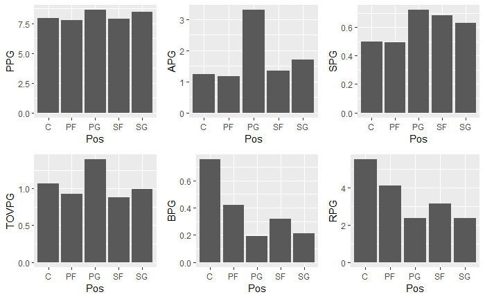

```r
points_graph <- ggplot(data=all_stats,aes(x=Pos,y=PPG ))+geom_bar(stat='identity',position='stack', width=.9)
assist_graph <- ggplot(data=all_stats,aes(x=Pos,y=APG ))+geom_bar(stat='identity',position='stack', width=.9)
block_graph <- ggplot(data=all_stats,aes(x=Pos,y=BPG ))+geom_bar(stat='identity',position='stack', width=.9)
turn_graph <- ggplot(data=all_stats,aes(x=Pos,y=TOVPG ))+geom_bar(stat='identity',position='stack', width=.9)
steal_graph <- ggplot(data=all_stats,aes(x=Pos,y=SPG ))+geom_bar(stat='identity',position='stack', width=.9)
rebound_graph <- ggplot(data=all_stats,aes(x=Pos,y=RPG ))+geom_bar(stat='identity',position='stack', width=.9)

final_stats <- plot_grid(points_graph, assist_graph, steal_graph, turn_graph, block_graph, rebound_graph)
final_stats
```